# Section 13

Chris Carter

April 23, 2019

## Agenda for Today

- Finishing RDD
- Missing data
- Spillover effects
- the F-test

## Exercise

[figure not shown]

We will use `rddata.Rda` to estimate the effect of having a left-wing party in office on social spending

```r
load("rddata.Rda")
head(data)
```

```
##   municipality  party  vs_2000  vs_2004 soc_spend
## 1            1 center 41.72421 36.56648  40.67018
## 2            1   left 43.23756 46.25497  48.98232
## 3            1  right 15.03822 17.17855  10.34750
## 4            2   left 33.82809 37.67917  37.96897
## 5            2  right 35.08161 37.52963  35.12098
## 6            2 center 31.09030 24.79119  26.91006
```

- What problems might we face using this dataset for our RDD?

```r
# How many municipalities?
length(unique(data$municipality))
```

```
## [1] 6000
```

```r
# How many candidates per municipality?
nr_cand <- NA
for (i in 1:6000){ nr_cand[i] <- nrow(data[data$municipality==i,]) }
mean(nr_cand)
```

```
## [1] 3
```

```r
sd(nr_cand)
```

```
## [1] 0
```

```r
# NA observations for running variable?
sum(is.na(data$vs_2000))
```

```
## [1] 0
```

What type of dataset do we need for the RD analysis? How can we build it?

```r
# Building RD dataset
rd_data <- NA

for (i in 1:6000){

    # get mini muni data
    temp <- data[data$municipality==i, ]
    # 1. keep winner and loser
    temp$order <- order(temp$vs_2000, decreasing = TRUE)
    temp <- temp[temp$order!=3, ]

    # 2. drop if no left
    temp$left <- ifelse(temp$party=="left", 1, 0)
    if (sum(temp$left)==0) {temp$margin <- NA}

    # 3. left margin
    if (sum(temp$left)==1){
        temp$margin <- temp$vs_2000[temp$left==1] -
            temp$vs_2000[temp$left==0]}

    # put together in final dataset
    rd_data <- rbind(rd_data, temp)

    if (i/1000==round(i/1000)) print(i)

}
```

```
## [1] 1000
## [1] 2000
## [1] 3000
## [1] 4000
## [1] 5000
## [1] 6000
```

```r
head(rd_data)
```

```
##   municipality  party  vs_2000  vs_2004 soc_spend order left    margin
## 1           NA   <NA>       NA       NA        NA    NA   NA        NA
## 2            1 center 41.72421 36.56648  40.67018     2    0  1.513347
## 3            1   left 43.23756 46.25497  48.98232     1    1  1.513347
## 4            2   left 33.82809 37.67917  37.96897     2    1 -1.253524
## 5            2  right 35.08161 37.52963  35.12098     1    0 -1.253524
## 7            3 center 34.91674 33.81395  37.22732     2    0  3.415483
```

```r
# dropping cases with no left wing party winner or runner up
rd_data <- rd_data[is.na(rd_data$margin)==F, ]
head(rd_data)
```

```
##   municipality  party  vs_2000  vs_2004 soc_spend order left    margin
## 2            1 center 41.72421 36.56648  40.67018     2    0  1.513347
## 3            1   left 43.23756 46.25497  48.98232     1    1  1.513347
## 4            2   left 33.82809 37.67917  37.96897     2    1 -1.253524
## 5            2  right 35.08161 37.52963  35.12098     1    0 -1.253524
## 7            3 center 34.91674 33.81395  37.22732     2    0  3.415483
## 8            3   left 38.33222 48.28878  47.91241     1    1  3.415483
```

```r
dim(rd_data)
```

```
## [1] 8100    8
```

```r
length(unique(rd_data$municipality))
```

```
## [1] 4050
```

```r
# creating the treatment variable
rd_data$treat <- ifelse(rd_data$left==1 & rd_data$margin>=0, 1, 0)
table(rd_data$treat)
```

```
##
##    0    1
## 6042 2058
```

```r
# keeping only the winner
rd_data <- rd_data[rd_data$order==1, ]
table(rd_data$treat)
```

```
##
##    0    1
## 2064 1986
```

```r
# t-test in 5% margin
with(rd_data[abs(rd_data$margin)<=5, ],
     t.test(soc_spend ~ treat))
```

```
##
##  Welch Two Sample t-test
##
## data:  soc_spend by treat
## t = -28.315, df = 1611.6, p-value < 2.2e-16
## alternative hypothesis: true difference in means is not equal to 0
## 95 percent confidence interval:
##  -8.875902 -7.725876
## sample estimates:
## mean in group 0 mean in group 1
##        36.22034        44.52122
```

## Robustness tests

- Varying cutpoint
- Test for discontinuities in covariates at cutpoint (which?)
- In fuzzy design, test significance of “first stage” discontinuity at cutpoint. How would that look here?

## Hidalgo - Electronic Voting

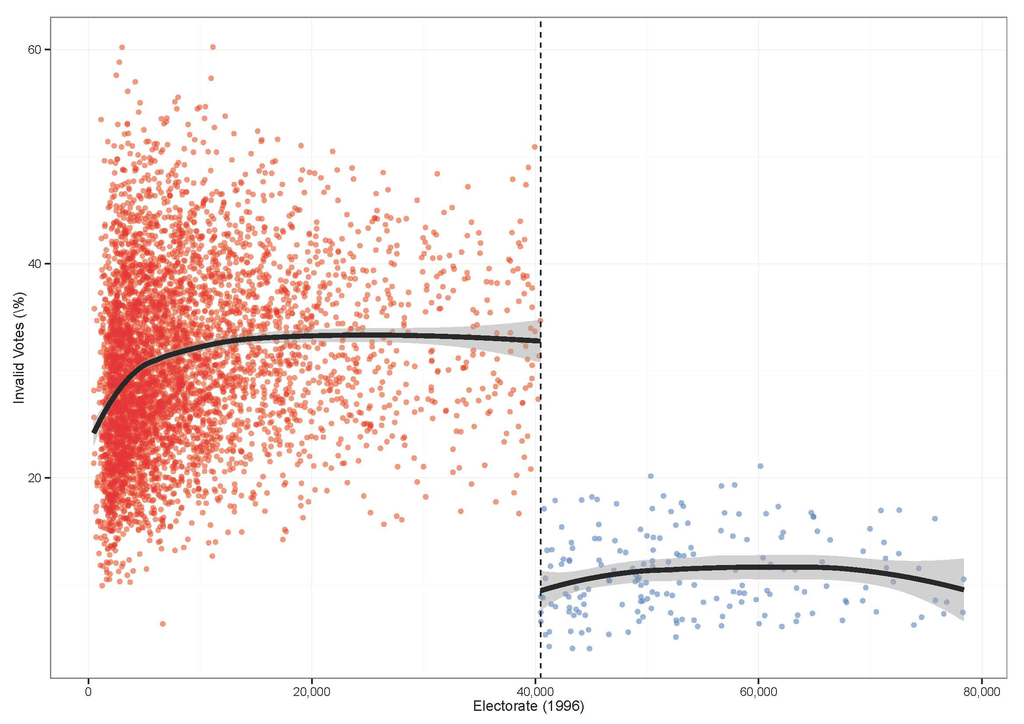

- Let’s imagine that Hidalgo looks at his data and finds that data for about 2% of polling places are missing in each state except Pernambuco, where 20% of the data is missing. Is this a problem? Why?
- What if 2% of the data were also missing from Pernambuco? Would that be a problem? Why or why not?
- How might Hidalgo address this problem?
- A key concern in experimental and observational work are spillovers.
- How do we define spillovers (AKA Sutva, interference)?
- Why are they an issue?

## Nickerson (2008): Is Voting Contagious?

Intra-household voter behavior is correlated, but how much of this is contagion?

Strategy: Treat only one voter in two-voter households, but measure the outcome for both voters.

Can we estimate the spillover effects by comparing treated and control households?

- If you only compare treated and control, you don’t know who would have answered the door for the control group.
- Why could this be a problem?

## Nickerson (2008): Is Voting Contagious?

Idea: placebo treatment.

A placebo treatment allows us to record who answers the door for both treatment and placebo group.

By identifying “primary” contacted and “secondarily” contacted units in each household, the spillover effect can be estimated.

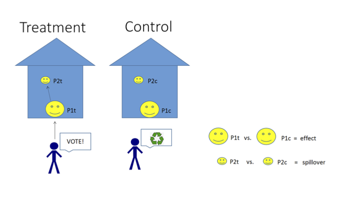

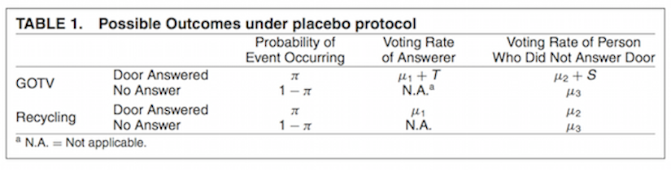

## Nickerson (2008): Is Voting Contagious?

# The data

```r
head(data)
```

```
##   family   city denver turf pct treatment reached other goaway moved can_t
## 1      1 DENVER      1   14  42         1       0     0      0     0     0
## 2      1 DENVER      1   14  42         1       0     0      0     0     0
## 3      2 DENVER      1   28  22         1       1     0      0     0     0
## 4      2 DENVER      1   28  22         1       0     1      0     0     0
## 5      3 DENVER      1   28  22         3       0     0      0     0     0
## 6      3 DENVER      1   28  22         3       0     0      0     0     0
##   hsecontact voted02p voted01 voted00 voted00p voted99 voted98      party
## 1          0        0       1       0        0       0       0 REPUBLICAN
## 2          0        0       1       1        0       0       1 REPUBLICAN
## 3          1        1       1       1        1       1       1 DEMOCRATIC
## 4          1        1       1       1        0       1       1 DEMOCRATIC
## 5          0        1       1       1        0       0       1 DEMOCRATIC
## 6          0        1       1       1        0       0       1 DEMOCRATIC
##   age gender
## 1  62      F
## 2  64      M
## 3  68      F
## 4  83      M
## 5  68      F
## 6  71      M
```

```r
table(data$reached, data$other)
```

```
##
##        0    1
##   0 5812  954
##   1  954    2
```

```r
table(data$treatment)
```

```
##
##    1    2    3
## 2572 2578 2572
```

## Replication

```r
contacted <- data[data$hsecontact==1, ]

table(contacted$treatment)
```

```
##
##   1   2
## 970 940
```

```r
contacted$treatment <- as.numeric(contacted$treatment==1)

table(contacted$treatment)
```

```
##
##   0   1
## 940 970
```

```r
direct <- with(contacted[contacted$reached==1, ],
               t.test(voted02p ~ treatment, alternative="less"))
direct
```

```
##
##  Welch Two Sample t-test
##
## data:  voted02p by treatment
## t = -3.0408, df = 953.07, p-value = 0.001212
## alternative hypothesis: true difference in means is less than 0
## 95 percent confidence interval:
##         -Inf -0.04267869
## sample estimates:
## mean in group 0 mean in group 1
##       0.2978723       0.3909465
```

```r
secondary <- with(contacted[contacted$other==1, ],
               t.test(voted02p ~ treatment, alternative="less"))
secondary
```

```
##
##  Welch Two Sample t-test
##
## data:  voted02p by treatment
## t = -1.8722, df = 953.81, p-value = 0.03074
## alternative hypothesis: true difference in means is less than 0
## 95 percent confidence interval:
##          -Inf -0.006791979
## sample estimates:
## mean in group 0 mean in group 1
##       0.2893617       0.3456790
```

## Nickerson by Nickerson

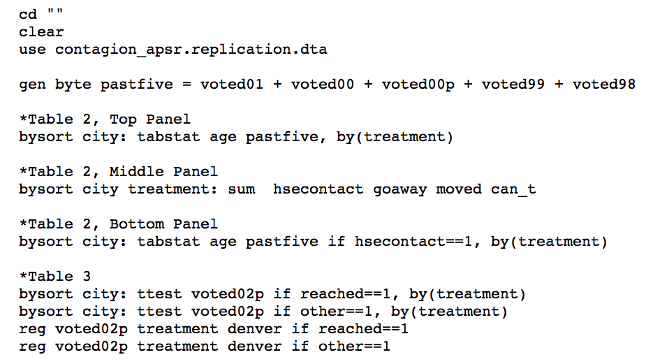

## Looking at balance in the Nickerson experiment

```r
names(contacted)
```

```
##  [1] "family"     "city"       "denver"     "turf"       "pct"
##  [6] "treatment"  "reached"    "other"      "goaway"     "moved"
## [11] "can_t"      "hsecontact" "voted02p"   "voted01"    "voted00"
## [16] "voted00p"   "voted99"    "voted98"    "party"      "age"
## [21] "gender"
```

```r
with(contacted, t.test(age ~ treatment))$p.value
```

```
## [1] 0.5341056
```

```r
with(contacted, t.test(gender ~ treatment))$p.value
```

```
## [1] 0.7191029
```

```r
with(contacted, t.test(party ~ treatment))$p.value
```

```
## [1] 0.840486
```

```r
with(contacted, t.test(voted01 ~ treatment))$p.value
```

```
## [1] 0.296065
```

## More balance tests

```r
with(contacted, t.test(voted00 ~ treatment))$p.value
```

```
## [1] 0.4156232
```

```r
with(contacted, t.test(voted00p ~ treatment))$p.value
```

```
## [1] 0.9677412
```

```r
with(contacted, t.test(voted99 ~ treatment))$p.value
```

```
## [1] 0.5504739
```

```r
with(contacted, t.test(voted98 ~ treatment))$p.value
```

```
## [1] 0.8231033
```

But how would we test whether the *set* of covariates can jointly predict treatment assignment better than chance?

## The F-test

The F-test is used to conduct a significant test for the joint hypothesis that all coefficients are zero. The null hypothesis is of the form $H0 : \beta_1 = \beta_2 = . . . = \beta_k = 0$.

We are comparing two models: one in which the coefficients of the pre-treatment covariates are allowed to vary and another in which they are constrained to zero.

The test statistic is:

$F_{0}=\frac{(SSR_{r}-SSR_{ur})/q}{SSR_{ur}/(n-(k+1))}$

where $SSR_{r}$ stands for the sum of the squared residuals of the restricted model and $SSR_{ur}$ sum of the suared residuals of the unrestricted model. $n$ is the number of observations, $k$ is the number of independent variables in the unrestricted model and $q$ is the number of restrictions (or the number of coefficients being jointly tested).

The regression output in `R` reports the F-test:

```r
reg <- with(contacted,
            lm(treatment ~ age + gender + party + voted01 + voted00 + voted00p + voted99 + voted98))
```

```r
summary(reg)
```

```
##
## Call:
## lm(formula = treatment ~ age + gender + party + voted01 + voted00 +
##     voted00p + voted99 + voted98)
##
## Residuals:
##     Min      1Q  Median      3Q     Max
## -0.5910 -0.5074  0.4491  0.4901  0.5611
##
## Coefficients:
##               Estimate Std. Error t value Pr(>|t|)
## (Intercept)  0.5627552  0.0469580  11.984   <2e-16 ***
## age         -0.0007298  0.0007489  -0.975    0.330
## gender      -0.0084457  0.0270020  -0.313    0.754
## party       -0.0046523  0.0263297  -0.177    0.860
## voted01      0.0353783  0.0276287   1.280    0.201
## voted00     -0.0481394  0.0393599  -1.223    0.221
## voted00p    -0.0093012  0.0291275  -0.319    0.750
## voted99      0.0184154  0.0283645   0.649    0.516
## voted98      0.0079868  0.0306426   0.261    0.794
## ---
## Signif. codes:  0 '***' 0.001 '**' 0.01 '*' 0.05 '.' 0.1 ' ' 1
##
## Residual standard error: 0.5006 on 1901 degrees of freedom
## Multiple R-squared:  0.002143,   Adjusted R-squared:  -0.002056
## F-statistic: 0.5103 on 8 and 1901 DF,  p-value: 0.8494
```

```r
names(summary(reg))
```

```
##  [1] "call"          "terms"         "residuals"     "coefficients"
##  [5] "aliased"       "sigma"         "df"            "r.squared"
##  [9] "adj.r.squared" "fstatistic"    "cov.unscaled"
```

```r
summary(reg)$fstatistic
```

```
##        value        numdf        dendf
##    0.5102919    8.0000000 1901.0000000
```

We can also calculate the F-test by hand. We first need $SSR_{ur}$.

```r
SSRur <- sum(reg$residuals^2)
SSRur
```

```
## [1] 476.3592
```

What about $SSR_{r}$. What is this restricted model?

```r
regr <- with(contacted, lm(treatment ~ 1))

SSRr <- sum(regr$residuals^2)
SSRr
```

```
## [1] 477.3822
```

What are $n$, $q$ and $k$?

$n$ is the number of observations,

```r
n <- nrow(contacted)
```

$k$ is the number of independent variables in the unrestricted model

```r
reg$coefficients
```

```
##  (Intercept)          age       gender        party      voted01
##  0.562755172 -0.000729799 -0.008445681 -0.004652306  0.035378272
##      voted00     voted00p      voted99      voted98
## -0.048139449 -0.009301187  0.018415401  0.007986835
```

```r
length(reg$coefficients)
```

```
## [1] 9
```

```r
k <- length(reg$coefficients) - 1
```

and $q$ is the number of restrictions.

```r
q <- length(reg$coefficients) - 1
```

Recall $F_{0}=\frac{(SSR_{r}-SSR_{ur})/q}{SSR_{ur}/(n-(k+1))}$

```r
df1 <- q
df2 <- n-(k+1)

F0 <- ((SSRr-SSRur)/df1) / (SSRur/df2)
F0
```

```
## [1] 0.5102919
```

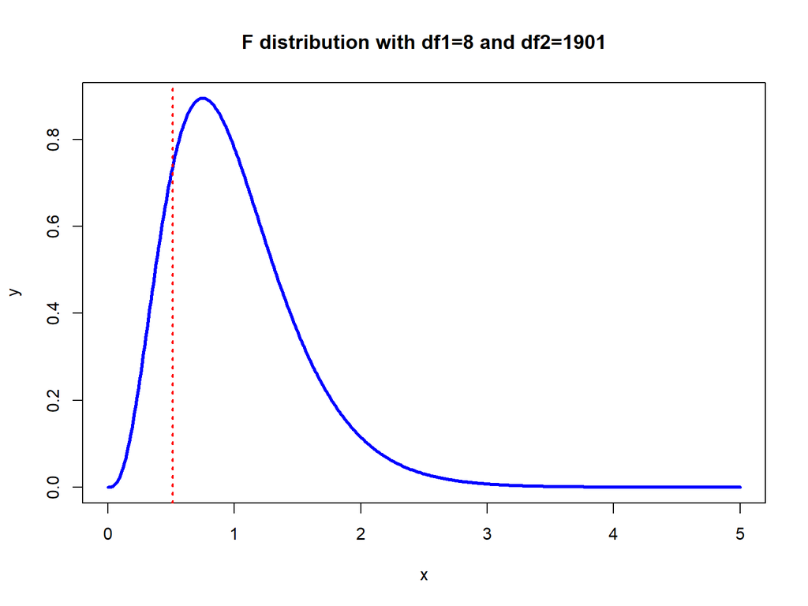

How do we calculate the p-value?

```r
F0
```

```
## [1] 0.5102919
```

```r
df1
```

```
## [1] 8
```

```r
df2
```

```
## [1] 1901
```

```r
1 - pf(F0, df1=df1, df2=df2)
```

```
## [1] 0.8494304
```

Does the validity of the test follow from the mechanical properties of OLS? What assumptions are we making?

We are assuming:

- treatment assignment is a linear combination of the covariates.
- normality of the error term in both regressions (where are we assuming this?)

Can we relax any of these assumptions?

## An alternative: randomization F-test

```r
library(ri)

perms <- genperms(Z=contacted$treatment)
```

```
## Too many permutations to use exact method.
## Defaulting to approximate method.
## Increase maxiter to at least Inf to perform exact estimation.
```

```r
dim(perms)
```

```
## [1]  1910 10000
```

```r
perm_f <- NULL

for (i in 1:ncol(perms)){

    contacted$treat <- perms[,i]

    reg <- with(contacted,
            lm(treat ~ age + gender + party + voted01 +
                   voted00 + voted00p + voted99 + voted98))

    perm_f[i] <- summary(reg)$fstatistic[1]

}

head(perm_f)
```

```
## [1] 1.9864167 0.3068202 1.2779482 0.3995489 1.1470463 0.9708967
```

```r
perm_fdist <- density(perm_f)
```

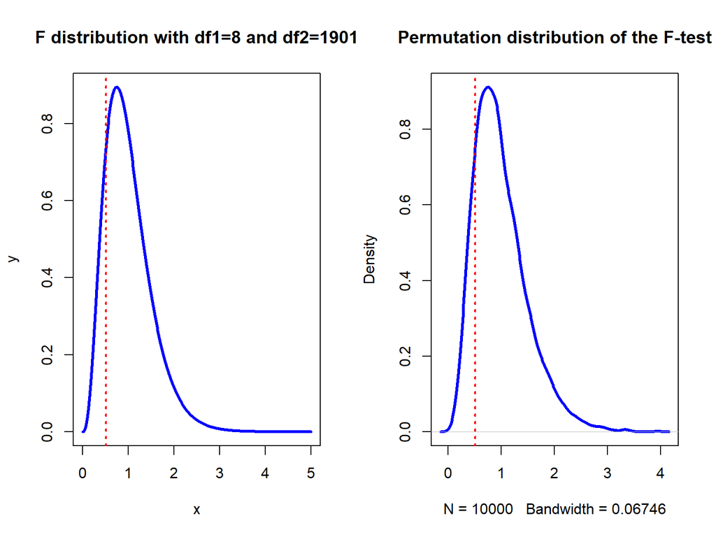